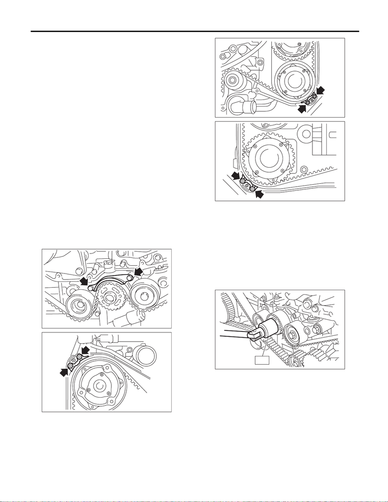

ME(STI)-51

Timing Belt

MECHANICAL

15.Timing Belt

A: REMOVAL

NOTE:

• When replacing a single part, perform the work

with the engine assembly installed to body.

• When performing the work with the engine in-

stalled to body, the following parts must also be re-

moved/installed.

• Radiator main fan motor assembly <Ref. to

CO(STI)-23, REMOVAL, Radiator Main Fan and

Fan Motor.> <Ref. to CO(STI)-23, INSTALLA-

TION, Radiator Main Fan and Fan Motor.>

• Radiator sub fan motor assembly <Ref. to

CO(STI)-25, REMOVAL, Radiator Sub Fan and

Fan Motor.> <Ref. to CO(STI)-25, INSTALLA-

TION, Radiator Sub Fan and Fan Motor.>

• When performing the work with the engine in-

stalled to body, protect the radiator with cardboards

or blankets.

1. TIMING BELT

1) Remove the crank pulley. <Ref. to ME(STI)-48,

REMOVAL, Crank Pulley.>

2) Remove the timing belt cover. <Ref. to ME(STI)-

50, REMOVAL, Timing Belt Cover.>

3) Remove the timing belt guide.

4) If the alignment mark or arrow mark (which indi-

cates the direction of rotation) on timing belt fade

away, put new marks before removing the timing

belt as shown in procedures below.

(1) Turn the crankshaft using ST, and align the

alignment marks on crank sprocket, intake cam

sprocket LH, exhaust cam sprocket LH, intake

cam sprocket RH and exhaust cam sprocket

RH with marks on oil pump and notches of tim-

ing belt cover.

ST 499987500 CRANKSHAFT SOCKET

ME-00230

ME-03124

ME-03125

ME-03126

ME-00231

ST

15WRX_STI_US_EN.book 51 ページ ２０１５年２月１３日 金曜日 午前１１時２０分

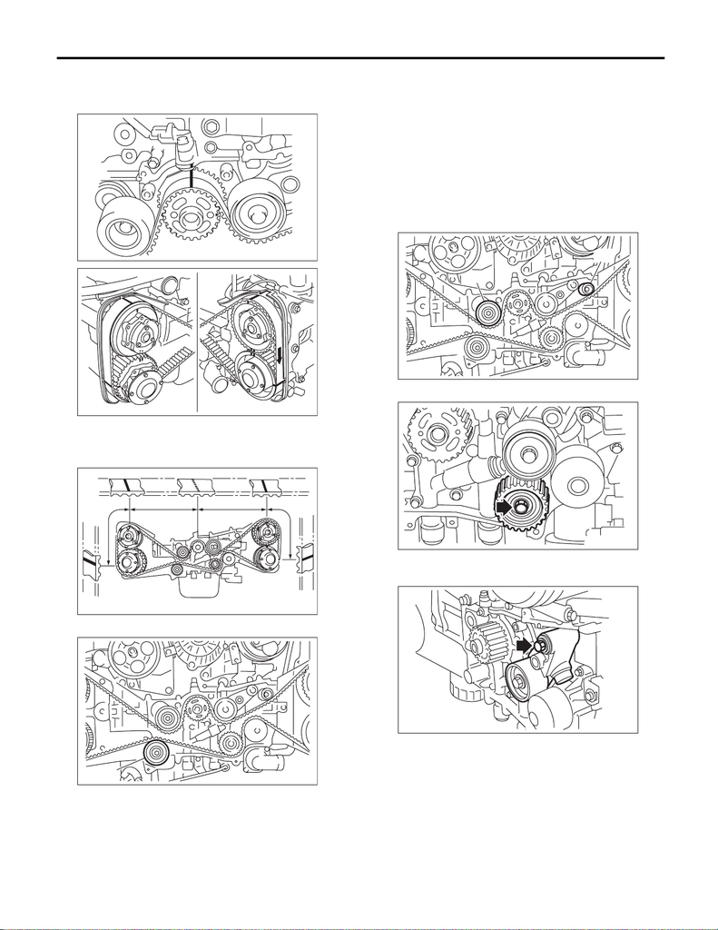

ME(STI)-52

Timing Belt

MECHANICAL

(2) Using white paint, put an alignment mark or

an arrow mark on timing belts in relation to the

crank sprocket and cam sprockets.

Z

1

: 54.5 teeth

Z

2

: 51 teeth

Z

3

: 28 teeth

5) Remove the belt idler (A).

6) Remove the timing belt.

CAUTION:

After the timing belt has been removed, never

rotate the intake and exhaust sprocket. If the

cam sprocket is rotated, the intake and exhaust

valve heads strike together and valve stems are

bent.

2. AUTOMATIC BELT TENSION ADJUST-

ER ASSEMBLY AND BELT IDLER

1) Remove the belt idler (A) and (B).

2) Remove the belt idler No. 2.

3) Remove the automatic belt tension adjuster as-

sembly.

ME-00070

ME-03127

ME-03128

Z

3

Z

1

Z

2

Z

3

(A)

ME-03935

(A)

(B)

ME-03936

ME-04977

ME-04978

15WRX_STI_US_EN.book 52 ページ ２０１５年２月１３日 金曜日 午前１１時２０分

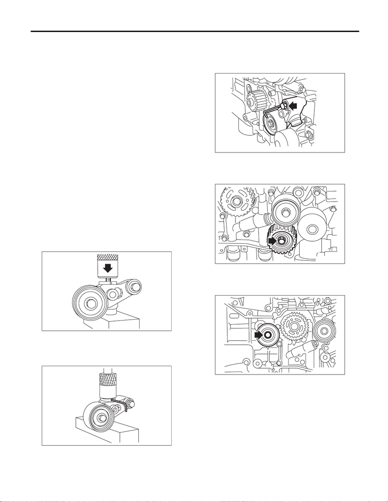

ME(STI)-53

Timing Belt

MECHANICAL

B: INSTALLATION

1. AUTOMATIC BELT TENSION ADJUST-

ER ASSEMBLY AND BELT IDLER

1) Prepare for installation of the automatic belt ten-

sion adjuster assembly.

CAUTION:

• Always use a vertical type pressing tool to

move the adjuster rod down.

• Do not use a lateral type vise.

• Push the adjuster rod vertically.

• Press-in the push adjuster rod gradually tak-

ing three minutes or more.

• Do not allow press pressure to exceed 9,807

N (1,000 kgf, 2,205 lbf).

• Push in the adjuster rod to the end face of the

cylinder. However, do not press the adjuster

rod below the end face of the cylinder. Doing so

may damage the cylinder.

• Do not release the press pressure until stop-

per pin is completely inserted.

(1) Attach the automatic belt tension adjuster

assembly to vertical pressing tool.

(2) Slowly push in the adjuster rod with a pres-

sure of 165 N (16.8 kgf, 37.1 lbf) or more until

the adjuster rod is aligned with the stopper pin

hole in the cylinder.

(3) With a 2 mm (0.08 in) dia. stopper pin or a 2

mm (nominal) dia. hex wrench inserted into the

stopper pin hole in cylinder, secure the adjuster

rod.

2) Install the automatic belt tension adjuster as-

sembly.

Tightening torque:

39 N·m (4.0 kgf-m, 28.8 ft-lb)

3) Install the belt idler No. 2.

Tightening torque:

39 N·m (4.0 kgf-m, 28.8 ft-lb)

4) Install the belt idlers.

Tightening torque:

39 N·m (4.0 kgf-m, 28.8 ft-lb)

ME-00239

ME-00350

ME-04979

ME-04977

ME-04980

15WRX_STI_US_EN.book 53 ページ ２０１５年２月１３日 金曜日 午前１１時２０分

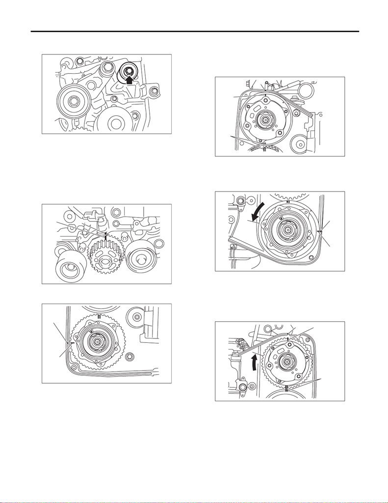

ME(STI)-54

Timing Belt

MECHANICAL

Tightening torque:

25 N·m (2.5 kgf-m, 18.4 ft-lb)

2. TIMING BELT

1) Prepare for installation of the automatic belt ten-

sion adjuster assembly. <Ref. to ME(STI)-53, AU-

TOMATIC BELT TENSION ADJUSTER

ASSEMBLY AND BELT IDLER, INSTALLATION,

Timing Belt.>

2) Align the mark (B) on crank sprocket with the

mark (A) on oil pump.

3) Align the single line mark (B) on the exhaust cam

sprocket RH with notch (A) on the timing belt cover.

4) Align the single line mark (B) on the intake cam

sprocket RH with notch (A) on the timing belt cover.

Make sure that the double line marks (C) on intake

cam sprocket and exhaust cam sprocket are

aligned.

5) Align the single line mark (B) on exhaust cam

sprocket LH with notch (A) on the timing belt cover

by turning the sprocket counterclockwise (as

viewed from front of engine).

6) Align the single line mark (B) on intake cam

sprocket LH with notch (A) on the timing belt cover

by turning the sprocket clockwise (as viewed from

front of engine). Make sure that the double line

marks (C) on intake cam sprocket and exhaust cam

sprocket are aligned.

ME-04981

(B)

ME-04082

(A)

ME-04083

(A)

(B)

ME-04084

(A)

(C)

(B)

ME-04085

(A)

(B)

ME-04086

(B)

(A)

(C)

15WRX_STI_US_EN.book 54 ページ ２０１５年２月１３日 金曜日 午前１１時２０分

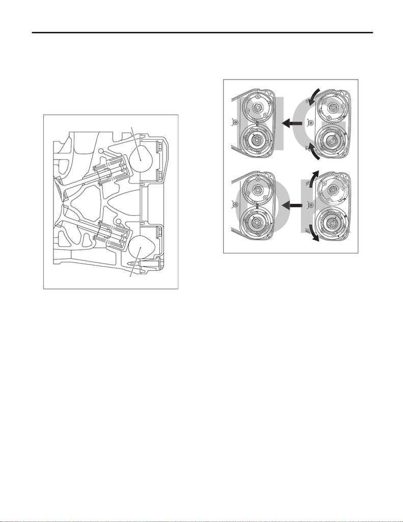

ME(STI)-55

Timing Belt

MECHANICAL

7) Make sure that the cam and crank sprockets are

positioned properly.

CAUTION:

• Intake and exhaust camshafts for this DOHC

engine can be independently rotated with the

timing belts removed. As can be seen from the

figure, if the intake and exhaust valves are lifted

simultaneously, heads will interfere with each

other, resulting in bent valves.

• When the timing belts are not installed, four

camshafts are held at the “zero-lift” position,

where all cams on camshafts are not pushing

down on the intake and exhaust valves. (Under

this condition, all valves remain unlifted.)

• When the camshafts are rotated to install the

timing belts, #2 intake and #4 exhaust cam of

camshaft LH are held, pushing their corre-

sponding valves down. (Under this condition,

these valves are held lifted.) Camshaft RH are

held so that their cams do not push the valves

down.

• Camshafts LH must be rotated from the zero-

lift position to the position where the timing belt

is to be installed with the smallest possible an-

gle, in order to prevent mutual interference of

intake and exhaust valve heads.

• Do not allow the camshafts to rotate in the di-

rection shown in the upper figure. Doing this

may cause both the intake and exhaust valves

to lift simultaneously, resulting in mutual inter-

ference of valve heads.

(A) Intake camshaft

(B) Exhaust camshaft

ME-04111

(A)

(B)

(A) Direction of rotation

(B) Timing belt installation position

(A)

(A)

(A)

(A)

(B)

(B)

ME-04717

15WRX_STI_US_EN.book 55 ページ ２０１５年２月１３日 金曜日 午前１１時２０分

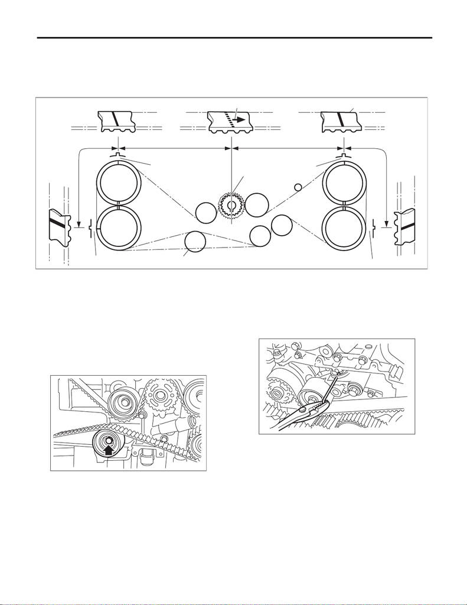

ME(STI)-56

Timing Belt

MECHANICAL

8) Align the alignment mark on the timing belt with marks on the sprockets in the alphabetical order shown

in the figure. While aligning marks, position the timing belt properly, and install the timing belt.

CAUTION:

• If the timing belt slips by 1 or more teeth, the valve and piston may hit each other.

• Make sure that the direction of belt rotation is correct.

9) Install the belt idlers.

Tightening torque:

39 N·m (4.0 kgf-m, 28.8 ft-lb)

NOTE:

Make sure that the marks on the timing belt and

sprockets are aligned.

10) After ensuring that the marks on the timing belt

and sprockets are aligned, remove the stopper pin

from tensioner adjuster.

(1) Arrow mark (4) 54.5 teeth (6) 28 teeth

(2) Timing belt (5) 51 teeth (7) Install it in the end

(3) 28 teeth

ME-04718

(1) (2)

(5)

(6)

(4)

(D)

(A)

(C)

(B)

(E)

(3)

RH-IN

RH-EX LH-EX

LH-IN

(7)

ME-04982

ME-00245

15WRX_STI_US_EN.book 56 ページ ２０１５年２月１３日 金曜日 午前１１時２０分

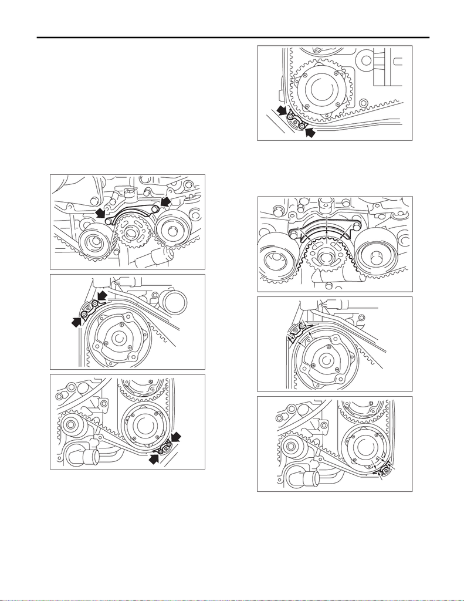

ME(STI)-57

Timing Belt

MECHANICAL

11) Install the timing belt guide.

(1) Temporarily tighten the bolts mounting the

timing belt guide.

NOTE:

• Before installing the timing belt guide, clean the

timing belt guide mounting bolt holes of the timing

belt cover No. 2.

• Apply liquid gasket to the thread of the timing belt

guide mounting bolt on the cam sprocket section.

(when reusing bolts)

Liquid gasket:

THREE BOND 1324 (Part No. 004403042) or

equivalent

(2) Adjust the clearance between timing belt

and timing belt guide using a thickness gauge

and tighten.

Clearance:

1.0

±

0.5 mm (0.039

±

0.020 in)

ME-00230

ME-03124

ME-03125

ME-03126

ME-00246

ME-03138

ME-03139

15WRX_STI_US_EN.book 57 ページ ２０１５年２月１３日 金曜日 午前１１時２０分

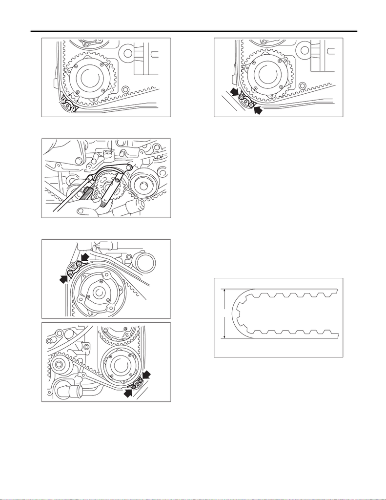

ME(STI)-58

Timing Belt

MECHANICAL

Tightening torque:

9.75 N·m (1.0 kgf-m, 7.2 ft-lb)

Tightening torque:

6.4 N·m (0.7 kgf-m, 4.7 ft-lb)

12) Install the timing belt cover. <Ref. to ME(STI)-

50, INSTALLATION, Timing Belt Cover.>

13) Install the crank pulley. <Ref. to ME(STI)-48,

INSTALLATION, Crank Pulley.>

C: INSPECTION

1. TIMING BELT

1) Check the timing belt teeth for breaks, cracks or

wear. If any fault is found, replace the timing belt.

2) Check the condition on the back surface of the

timing belt. If cracks are found, replace the timing

belt.

CAUTION:

• Be careful not to let oil, grease or coolant

contact the timing belt. Remove quickly and

thoroughly if this happens.

• Do not bend the timing belt sharply.

In radial diameter h:

60 mm (2.36 in) or more

ME-03140

ME-00247

ME-03124

ME-03125

ME-03126

ME-00248

h

15WRX_STI_US_EN.book 58 ページ ２０１５年２月１３日 金曜日 午前１１時２０分

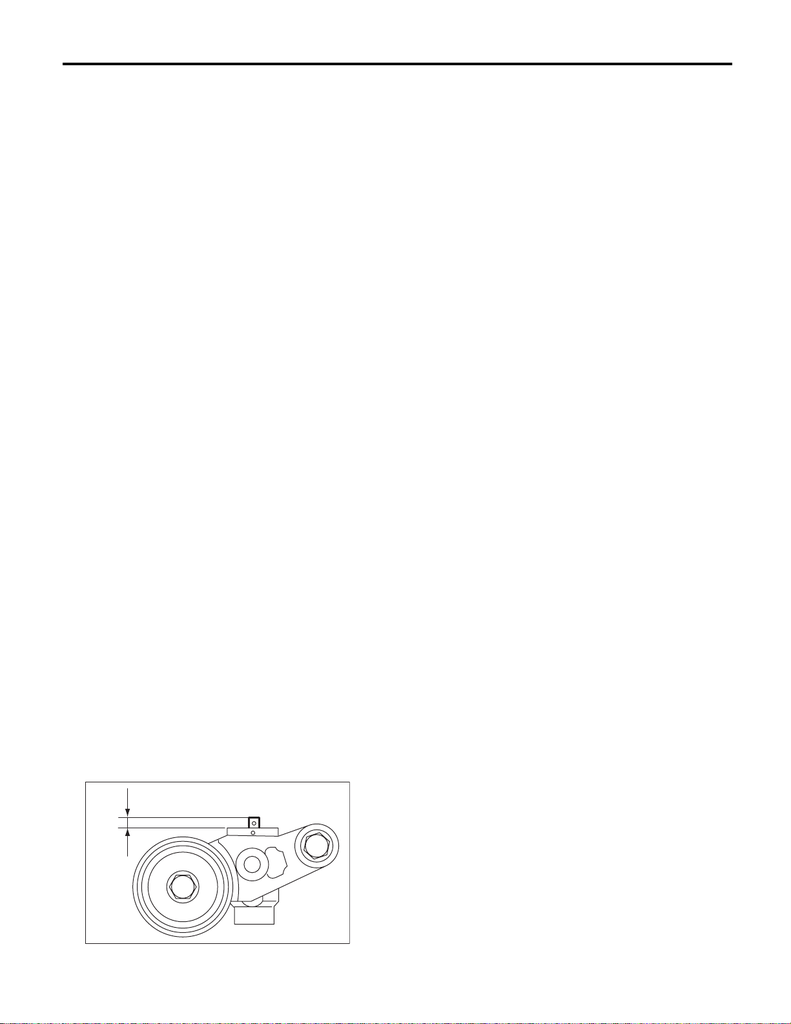

ME(STI)-59

Timing Belt

MECHANICAL

2. AUTOMATIC BELT TENSION ADJUST-

ER

1) Visually check the oil seals for leaks, and rod

ends for abnormal wear and scratches. If neces-

sary, replace the automatic belt tension adjuster

assembly.

NOTE:

Slight traces of oil at the rod oil seal does not indi-

cate a problem.

2) Check that the adjuster rod does not move when

a pressure of 165 N (16.8 kgf, 37.1 lbf) is applied to

it. This is to check adjuster rod stiffness.

3) If the adjuster rod is not stiff enough and moves

freely when applying 165 N (16.8 kgf, 37.1 lbf),

check it using the following procedures:

(1) Slowly press the adjuster rod down to the

end surface of cylinder. Repeat this operation

two to three times.

(2) With the adjuster rod moved all the way up,

apply a pressure of 165 N (16.8 kgf, 37.1 lbf) to

it, and check the adjuster rod stiffness.

(3) If the adjuster rod is not stiff and moves

down, replace the automatic belt tension adjust-

er assembly with a new part.

CAUTION:

• Always use a vertical type pressing tool to

move the adjuster rod down.

• Do not use a lateral type vise.

• Push the adjuster rod vertically.

• Press-in the push adjuster rod gradually tak-

ing three minutes or more.

• Do not allow press pressure to exceed 9,807

N (1,000 kgf, 2,205 lbf).

• Push in the adjuster rod to the end face of the

cylinder. However, do not press the adjuster

rod below the end face of the cylinder. Doing so

may damage the cylinder.

4) Measure the amount of adjuster rod protrusion

“L” from the end surface of the cylinder. If it is not

within specifications, replace the automatic belt

tension adjuster assembly with a new part.

Protrusion amount of adjuster rod L:

5.2 — 6.2 mm (0.205 — 0.244 in)

3. BELT TENSION PULLEY

1) Check the mating surfaces of timing belt and

contact point of adjuster rod for abnormal wear or

scratches. Replace the automatic belt tension ad-

juster assembly with a new part if faulty.

2) Check the belt tension pulley for smooth rota-

tion. Replace the automatic belt tension adjuster

assembly with a new part if abnormal noise or ex-

cessive play occurs.

3) Check the belt tension pulley for grease leakage.

4. BELT IDLER

1) Check the belt idler for smooth rotation. Replace

if noise or excessive play occurs.

2) Check the outer contacting surfaces of idler pul-

ley for abnormal wear and scratches.

3) Check the belt idler for grease leakage.

ME-04106

L

15WRX_STI_US_EN.book 59 ページ ２０１５年２月１３日 金曜日 午前１１時２０分